# Practica General - Curso R

María Sánchez García

1/14/2022

Primero instalamos y/o cargamos todos los paquetes necesarios para desarrollar el código (las citas están al final del documento)

```r
library(dplyr)
library(plyr)
library(tidyverse)
```

Ahora cargamos los datos de palmerpenguins con los que vamos a trabajar

```r
library(palmerpenguins)
data(package = "palmerpenguins")
```

Extraemos los datos del paquete y analizamos su estructura

```r
data("penguins")
str(penguins)   #estructura
class(penguins) #tipo
names(penguins) #nombres de las variables
summary(penguins) #resumen de los datos

str(penguins_raw)
class(penguins_raw)
names(penguins_raw)
summary(penguins_raw)
```

#### (1) Número de individuos totales, masculinos y femeninos por especie

Para este punto la información viene en ambas variables (“penguins” y “penguins_raw”), pero utilizamos “penguins” por simplicidad.

```r
sp_sex <- table(penguins$species, penguins$sex) #tabla de frecuencia
sp_sex
```

```
##
##             female male
##   Adelie        73   73
##   Chinstrap     34   34
##   Gentoo        58   61
```

```r
sizes <- penguins %>%
  dplyr::group_by(species) %>% #se agrupan los datos por especies
  dplyr::summarise(bill_lenght_mean = mean(bill_length_mm, na.rm = TRUE), bill_lenght_sd = sd(bill_length_mm, na.rm = TRUE), bill_depth_mean = mean(bill_depth_mm, na.rm = TRUE), bill_depth_sd = sd(bill_depth_mm, na.rm = TRUE), flipper_length_mean = mean(flipper_length_mm, na.rm = TRUE), flipper_length_sd = sd(flipper_length_mm, na.rm = TRUE), body_mass_mean = mean(body_mass_g, na.rm = TRUE), body_mass_sd = sd(body_mass_g, na.rm = TRUE))
#se incluye la media y la desviacion estandar de los parametros requeridos

sizes
```

```
## # A tibble: 3 × 9
##   species   bill_lenght_mean bill_lenght_sd bill_depth_mean bill_depth_sd
##   <fct>                <dbl>          <dbl>           <dbl>         <dbl>
## 1 Adelie                38.8           2.66            18.3         1.22
## 2 Chinstrap             48.8           3.34            18.4         1.14
## 3 Gentoo                47.5           3.08            15.0         0.981
## # … with 4 more variables: flipper_length_mean <dbl>, flipper_length_sd <dbl>,
## #   body_mass_mean <dbl>, body_mass_sd <dbl>
```

#### (2) Un gráfico de barras que represente el número de individuos muestreados de cada especie en cada isla.

Representando las especies en diferentes colores (Chinstrap – morado, Gentoo – azul, Adelie – naranja).

Cargamos paquete ggplot para graficar

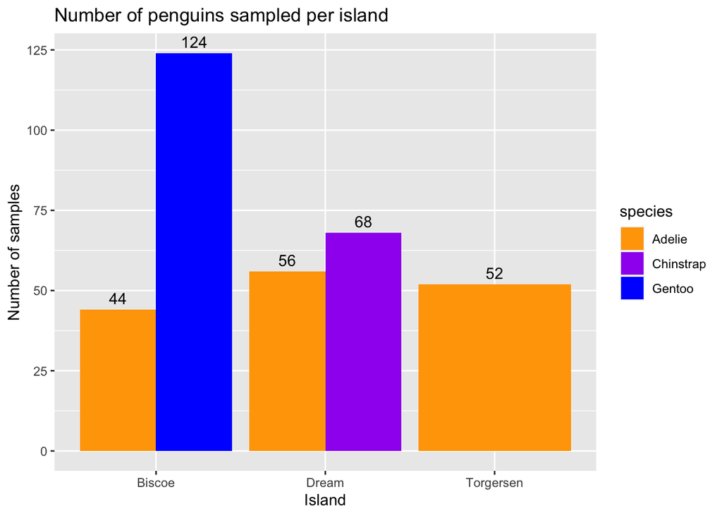

```r
library(ggplot2)
library(scales)
ggplot(data = penguins, aes(x = island, fill = species)) +
  geom_bar(position = "dodge") +
  scale_fill_manual(values = c("orange","purple","blue")) +
  scale_y_continuous(breaks = c(0, 25, 50, 75, 100, 125, 150, 175)) +
  geom_text(aes(label = ..count..), stat= "count", position = position_dodge(0.9), vjust = -0.5) +
  labs(y = "Number of samples", x = "Island", title = "Number of penguins sampled per island")
```

#### Contesta a las siguientes preguntas:

##### 1) ¿Qué especie se ha muestreado en las tres islas?

Adeile

##### 2) ¿Cuántos individuos se han muestreado de la isla Dream?

124

```r
table(penguins$island)
```

```
##
##    Biscoe     Dream Torgersen
##       168       124        52
```

#### (3) Un gráfico multipanel de cajas y bigotes del tamaño de los pingüinos según su sexo, donde aparezca un panel para cada especie.

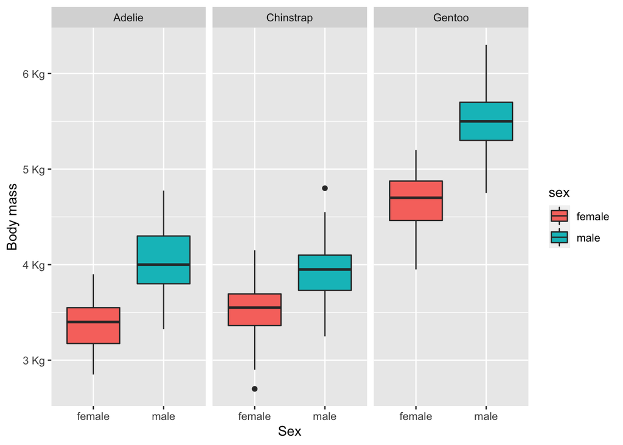

```r
datos <- penguins[!is.na(penguins$sex),] #se quitan los NA de la variable "sexo"

ggplot(data = datos, aes(x = sex, y = body_mass_g, fill = sex)) +
  geom_boxplot() +
  facet_grid(cols = vars(species), scales = "free") +
  labs(x = "Sex", y = "Body mass") +
  scale_y_continuous(labels = label_number_si(unit = "g"))
```

#### Contesta a las siguientes preguntas:

##### ¿Qué especie tiene mayor tamaño?

Gentoo

```r
datos %>%
  group_by(species) %>%
  dplyr::summarise(body_mass_g = max(body_mass_g))
```

```
## # A tibble: 3 × 2
##   species   body_mass_g
##   <fct>           <int>
## 1 Adelie           4775
## 2 Chinstrap        4800
## 3 Gentoo           6300
```

##### ¿En qué especie las hembras y los machos tienen un tamaño más similar?

Chinstrap

```r
datos %>%
  dplyr::group_by(species, sex) %>%
  dplyr::summarise(body_mass_g = mean(body_mass_g))
```

```
## # A tibble: 6 × 3
## # Groups:   species [3]
##   species   sex    body_mass_g
##   <fct>     <fct>        <dbl>
## 1 Adelie    female       3369.
## 2 Adelie    male         4043.
## 3 Chinstrap female       3527.
## 4 Chinstrap male         3939.
## 5 Gentoo    female       4680.
## 6 Gentoo    male         5485.
```

#### Referencias de los paquetes utilizados:

```r
citation("base")
citation("dplyr")
citation("plyr")
citation("tidyverse")
citation("palmerpenguins")
citation("ggplot2")
citation("scales")
```

1. R Core Team (2020). R: A language and environment for statistical computing. R Foundation for Statistical Computing, Vienna, Austria. URL https://www.R-project.org/.
2. Hadley Wickham, Romain François, Lionel Henry and Kirill Müller (2021). dplyr: A Grammar of Data Manipulation. R package version 1.0.7. https://CRAN.R-project.org/package=dplyr
3. Hadley Wickham (2011). The Split-Apply-Combine Strategy for Data Analysis. Journal of Statistical Software, 40(1), 1-29. URL http://www.jstatsoft.org/v40/i01/.
4. Wickham et al., (2019). Welcome to the tidyverse. Journal of Open Source Software, 4(43), 1686, https://doi.org/10.21105/joss.01686
5. Horst AM, Hill AP, Gorman KB (2020). palmerpenguins: Palmer Archipelago (Antarctica) penguin data. R package version 0.1.0. https://allisonhorst.github.io/palmerpenguins/
6. H. Wickham. ggplot2: Elegant Graphics for Data Analysis. Springer-Verlag New York, 2016.
7. Hadley Wickham and Dana Seidel (2020). scales: Scale Functions for Visualization. R package version 1.1.1. https://CRAN.R-project.org/package=scales